# Analfabetismo en el Perú

### Indice

- Hipótesis 1
- Hipótesis 2
- Hipótesis 3
- Hipótesis 4
- Hipótesis 5
- Hipótesis 6
- Hipótesis 7
- Annova
- [Analisis ]

### Información General

En primer lugar, se considera a una persona como analfabeta cuando tiene 15 y más años de edad y no sabe leer ni escribir. Las preguntas para captar a la población analfabeta y alfabeta en la Encuesta Nacional de Hogares tienen el siguiente procedimiento:

1. Se pregunta el nivel de educación logrado de las personas entrevistadas.
2. A las personas con primaria incompleta o menor nivel educativo, se les consulta si tienen la habilidad de leer y escribir.
3. A las personas que respondieron afirmativamente, se les pide leer una cartilla para corroborar si efectivamente saben leer.

### Hipótesis 1

El dato más mencionado en los trabajos académicos ha sido que los espacios rurales son los que mayor presentan niveles de analfabetismo, es por ello que considerarlo una variable que afecta a la dependiente es fundamental. Esto es posible a que las zonas rurales cuentan con menos accesos a servicios educativos, subiendo el porcentaje de personas analfabetas. Según los resultados se han encontrado que el coeficiente es altamente significativo (p<0.001), lo que indica una fuerte asociación positiva entre el porcentaje de zonas rurales y el porcentaje de analfabetismo.Sin embargo, se encuentra que otras variables podrían ayudar al modelo

#### **1.1. Resultado del modelo**

```
Call:
lm(formula = mi_tabla$PORCENTAJEANALFABETISMO ~ mi_tabla$`Rural porcentaje`)

Residuals:
     Min       1Q   Median       3Q      Max
-13.4631  -3.3179  -0.4789   3.2180  18.6183

Coefficients:
                            Estimate Std. Error t value Pr(>|t|)
(Intercept)                   5.4432     0.7798   6.981 4.78e-11 ***
mi_tabla$`Rural porcentaje`  13.1021     1.2535  10.453  < 2e-16 ***
---
Signif. codes:  0 '***' 0.001 '**' 0.01 '*' 0.05 '.' 0.1 ' ' 1

Residual standard error: 5.141 on 190 degrees of freedom
Multiple R-squared:  0.3651,    Adjusted R-squared:  0.3618
F-statistic: 109.3 on 1 and 190 DF,  p-value: < 2.2e-16
```

Regresion: modelo 1

|  | Resultado |
| --- | --- |
| (Intercept) | 5.443*** |
|  | (0.780) |
| mi_tabla$Rural porcentaje | 13.102*** |
|  | (1.253) |
| Num.Obs. | 192 |
| R2 | 0.365 |
| R2 Adj. | 0.362 |
| AIC | 1177.6 |
| BIC | 1187.3 |
| Log.Lik. | -585.780 |
| RMSE | 5.11 |

+ p < 0.1, * p < 0.05, ** p < 0.01, *** p < 0.001

#### **1.1. Gráfico del modelo**

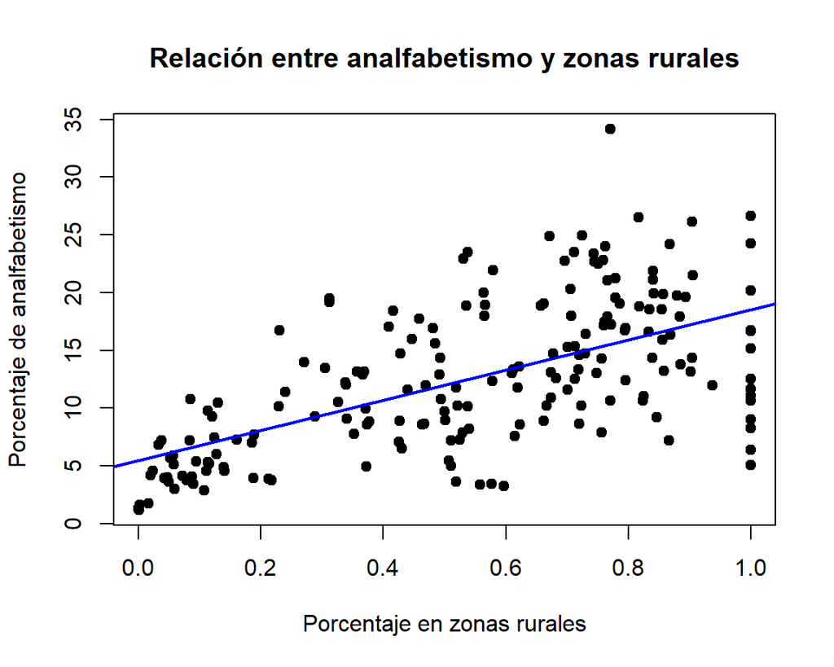